# Praca domowa 4

Ola Paluszynska

25 marca 2017

# Dane do analizy interakcji

Naszym zadaniem jest podanie przykładu zbioru danych, dla którego ma sens zastosowanie analizy interakcji typu crossed i nested. Przytoczymy więc wybrany zbiór danych i uzasadnimy przydatność obu typów analiz.

## World Values Survey

Wykorzystamy dane z szóstej fali ankiety World Values Survey, które dostępne są pod adresem internetowym http://www.worldvaluessurvey.org/WVSDocumentationWV6.jsp. Dane dostępne są w kilku formatach (m.in. rdata) i aby je pobrać należy podać swoje podstawowe dane, określić cel wykorzystania danych oraz zaakceptować regulamin.

```r
setwd("~/UW/Modele_Liniowe_i_Mieszane")
load("WV6_Data_R_v_2016_01_01.rdata")
data <- WV6_Data_R; rm(WV6_Data_R)
```

```r
head(cbind(colnames(data), attr(data, "var.labels")), n = 15)
```

```
##       [,1]  [,2]
##  [1,] "V1"  "Wave"
##  [2,] "V2"  "Country Code"
##  [3,] "V2A" "Country/regions [with split ups]"
##  [4,] "V3"  "Interview number"
##  [5,] "V4"  "Important in life: Family"
##  [6,] "V5"  "Important in life: Friends"
##  [7,] "V6"  "Important in life: Leisure time"
##  [8,] "V7"  "Important in life: Politics"
##  [9,] "V8"  "Important in life: Work"
## [10,] "V9"  "Important in life: Religion"
## [11,] "V10" "Feeling of happiness"
## [12,] "V11" "State of health (subjective)"
## [13,] "V12" "Important child qualities: independence"
## [14,] "V13" "Important child qualities: Hard work"
## [15,] "V14" "Important child qualities: Feeling of responsibility"
```

## Analizowane zmienne

Do naszej analizy jako zmienną objaśnianą wykorzystamy decyl dochodu (`income`), przy czym ze względu na jego dużą liczbę kategorii (10) potraktujemy go jako zmienną ciągłą. Jako zmienne objaśniające wykorzystamy zmienną ilościową (dyskretną, ale traktujemy jako ciągłą) wiek (`age`) oraz zmienne jakościowe kraj (`country`), płeć (`sex`) oraz najwyższy osiągnięty poziom wykształcenia (`education`). Poniżej wybieramy te zmienne ze zbioru:

```r
df <- data[,c("V239", "V240", "V242", "V248", "V2")]
colnames(df) <- c("income", "sex", "age", "education", "country")
df[df < 0] <- NA # wartości poniżej zera to różne rodzaje braków danych
df <- df[!is.na(df$income),] # usuwamy braki danych zmiennej objaśnianej
```

Musimy jeszcze przetworzyć zmienne jakościowe z numerycznych w jakościowe i nadać im odpowiednie etykiety:

```r
df$sex <- factor(df$sex, levels = attr(data, "label.table")[[309]], labels = names(attr(data, "label.table")[[309]]))
df$education <- factor(df$education, levels = attr(data, "label.table")[[319]], labels = names(attr(data, "label.table")[[319]]))
df$country <- factor(df$country, levels = attr(data, "label.table")[[2]], labels = names(attr(data, "label.table")[[2]]))
for(i in c("sex", "education", "country")){
    df[,i] <- droplevels(df[,i])
}
```

## Interakcja typu crossed

### Wpływ płci i wieku na dochód

Wydaje się, że zarówno płeć (tzw. gender gap) jak i wiek (proxy doświadczenia zawodowego) mają wpływ na poziom dochodów. Można by się również spodziewać, że zależność dochodu od wieku jest różna dla każdej z płci, ze względu na różnice między kobietami a mężczyznami związane z wiekiem - np. kobiety w młodości często poświęcają część swojego czasu na macierzyństwo, co może powodować mniejszy wzrost zarobków wraz z wiekiem niż ma to miejsce u mężczyzn. Poniżej przedstawiamy `interaction.plot` dla tych zmiennych, na którym krzywe przecinają się wielokrotnie, co sugeruje występowanie interakcji.

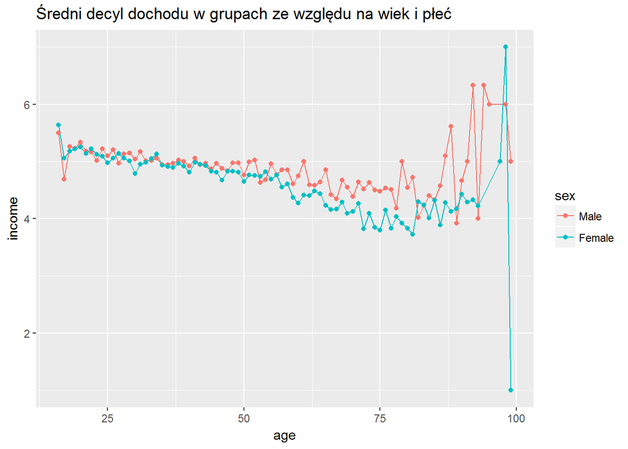

```r
library(ggplot2)
ggplot(df[!is.na(df$sex),], aes(x = age, y = income, colour = sex, group = sex)) + stat_summary(fun.y = mean, geom = "line") + stat_summary(fun.y = mean, geom = "point") + ggtitle("Średni decyl dochodu w grupach ze względu na wiek i płeć")
```

Podejście typu crossed jest w tym przypadku uzasadnione, gdyż spodziewamy się różnicy we współczynniku nachylenia dla wieku między kobietami i mężczyznami ogółem. Moglibyśmy również argumentować, że w każdym wieku efekt płci jest inny, co uzasadniałoby podejście nested, jednak w tym przypadku wydaje się to nieco naciągane.

Warto zaznaczyć, że w modelowaniu dochodów zwykle uwzględnia się nie tylko wiek, ale również kwadrat wieku, gdyż zarówno bardzo młodzi, jak i bardzo starzy ludzie zarabiają średnio mniej (zależność ta jest kwadratowa). W naszym modelu uwzględnimy zatem interakcję płci z całym wielomianem wieku.

```r
anova(modelSexAge <- lm(income ~ sex + age + I(age^2) + sex*age + sex*I(age^2), data = df))
```

```
## Analysis of Variance Table
##
## Response: income
##                 Df Sum Sq Mean Sq  F value    Pr(>F)
## sex              1    457   457.3  104.473 < 2.2e-16 ***
## age              1   5787  5787.4 1322.141 < 2.2e-16 ***
## I(age^2)         1     95    94.7   21.630 3.311e-06 ***
## sex:age          1    308   307.5   70.249 < 2.2e-16 ***
## sex:I(age^2)     1     54    54.3   12.402 0.0004292 ***
## Residuals    87066 381114     4.4
## ---
## Signif. codes:  0 '***' 0.001 '**' 0.01 '*' 0.05 '.' 0.1 ' ' 1
```

Przedstawione powyżej wyniki analizy wariancji wskazują na istotność każdego efektu z osobna oraz ich obu interakcji. Oszacowania parametrów modelu są następujące:

```r
summary(modelSexAge)
```

```
##
## Call:
## lm(formula = income ~ sex + age + I(age^2) + sex * age + sex *
##     I(age^2), data = df)
##
## Residuals:
##     Min      1Q  Median      3Q     Max
## -4.2424 -1.4785  0.0289  1.3707  6.2568
##
## Coefficients:
##                      Estimate Std. Error t value Pr(>|t|)
## (Intercept)         5.412e+00  7.076e-02  76.481  < 2e-16 ***
## sexFemale          -1.521e-01  9.899e-02  -1.536 0.124430
## age                -1.032e-02  3.358e-03  -3.074 0.002112 **
## I(age^2)           -1.748e-05  3.608e-05  -0.485 0.627988
## sexFemale:age       8.870e-03  4.659e-03   1.904 0.056922 .
## sexFemale:I(age^2) -1.754e-04  4.980e-05  -3.522 0.000429 ***
## ---
## Signif. codes:  0 '***' 0.001 '**' 0.01 '*' 0.05 '.' 0.1 ' ' 1
##
## Residual standard error: 2.092 on 87066 degrees of freedom
##   (154 observations deleted due to missingness)
## Multiple R-squared:  0.01728,    Adjusted R-squared:  0.01722
## F-statistic: 306.2 on 5 and 87066 DF,  p-value: < 2.2e-16
```

Powyższe oszacowania wskazują na brak różnicy w średnich dochodach między kobietami i mężczyznami. Przy poziomie istotności 0.1 nachylenie dla wieku jest ujemne i mniejsze dla mężczyzn, natomiast kwadratowa zależność wieku i zarobków występuje jedynie u kobiet.

### Wpływ płci i wykształcenia na dochód

Jako drugi przykład analizy crossed podamy model objaśniający zarobki płcią, wykształceniem oraz ich interakcją. Naszą hipotezą jest to, że wykształcenie kobiet jest traktowane inaczej, niż wykształcenie mężczyzn (może to być związane np. z tym, że kobiety wybierają średnio częściej wykształcenie innego rodzaju - nasza zmienna informuje jedynie o jego poziomie).

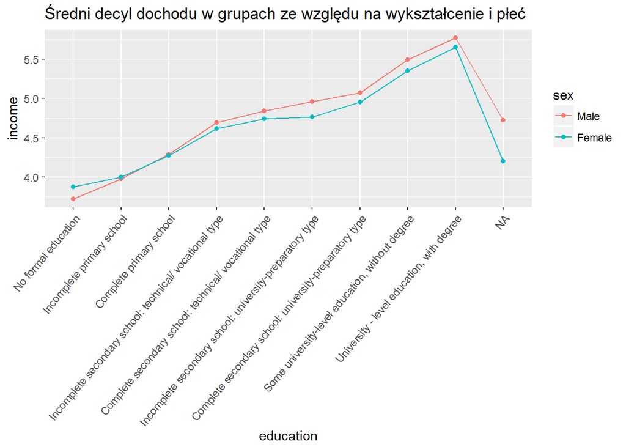

```r
ggplot(df[!is.na(df$sex),], aes(x = education, y = income, colour = sex, group = sex)) + stat_summary(fun.y = mean, geom = "line") + stat_summary(fun.y = mean, geom = "point") + theme(axis.text.x=element_text(angle = 50, hjust = 1)) + ggtitle("Średni decyl dochodu w grupach ze względu na wykształcenie i płeć")
```

```r
anova(modelSexEdu <- lm(income ~ sex*education, data = df))
```

```
## Analysis of Variance Table
##
## Response: income
##                  Df Sum Sq Mean Sq  F value    Pr(>F)
## sex               1    433   432.8 104.5379 < 2.2e-16 ***
## education         8  26401  3300.1 797.0548 < 2.2e-16 ***
## sex:education     8    131    16.4   3.9513 0.0001095 ***
## Residuals     86514 358204     4.1
## ---
## Signif. codes:  0 '***' 0.001 '**' 0.01 '*' 0.05 '.' 0.1 ' ' 1
```

```r
summary(modelSexEdu)
```

```
##
## Call:
## lm(formula = income ~ sex * education, data = df)
##
## Residuals:
##     Min      1Q  Median      3Q     Max
## -4.7732 -1.4917  0.1224  1.2799  6.2799
##
## Coefficients:
##                                                                             Estimate Std. Error t value Pr(>|t|)
## (Intercept)                                                                  3.72010    0.04650  80.005  < 2e-16 ***
## sexFemale                                                                    0.15750    0.05812   2.710 0.006727 **
## educationIncomplete primary school                                           0.25581    0.06332   4.040 5.34e-05 ***
## educationComplete primary school                                             0.57150    0.05558  10.282  < 2e-16 ***
## educationIncomplete secondary school: technical/ vocational type             0.97582    0.05840  16.708  < 2e-16 ***
## educationComplete secondary school: technical/ vocational type               1.12416    0.05187  21.674  < 2e-16 ***
## educationIncomplete secondary school: university-preparatory type            1.23998    0.05804  21.365  < 2e-16 ***
## educationComplete secondary school: university-preparatory type              1.35124    0.05216  25.906  < 2e-16 ***
## educationSome university-level education, without degree                     1.77156    0.05790  30.596  < 2e-16 ***
## educationUniversity - level education, with degree                           2.05315    0.05199  39.492  < 2e-16 ***
## sexFemale:educationIncomplete primary school                                -0.13305    0.08203  -1.622 0.104803
## sexFemale:educationComplete primary school                                  -0.17807    0.07158  -2.487 0.012867 *
## sexFemale:educationIncomplete secondary school: technical/ vocational type  -0.23363    0.07715  -3.028 0.002461 **
## sexFemale:educationComplete secondary school: technical/ vocational type    -0.26003    0.06633  -3.920 8.86e-05 ***
## sexFemale:educationIncomplete secondary school: university-preparatory type -0.35212    0.07610  -4.627 3.72e-06 ***
## sexFemale:educationComplete secondary school: university-preparatory type   -0.27095    0.06684  -4.054 5.04e-05 ***
## sexFemale:educationSome university-level education, without degree          -0.29560    0.07648  -3.865 0.000111 ***
## sexFemale:educationUniversity - level education, with degree                -0.27637    0.06679  -4.138 3.51e-05 ***
## ---
## Signif. codes:  0 '***' 0.001 '**' 0.01 '*' 0.05 '.' 0.1 ' ' 1
##
## Residual standard error: 2.035 on 86514 degrees of freedom
##   (694 observations deleted due to missingness)
## Multiple R-squared:  0.07001,    Adjusted R-squared:  0.06983
## F-statistic: 383.1 on 17 and 86514 DF,  p-value: < 2.2e-16
```

Jak widać, zarówno pojedyncze efekty jak i ich interakcja są istotne, natomiast oszacowania parametrów wskazują dokładnie na to, co było na wykresie, czyli na niższy wzrost zarobków związanych z wykształceniem u kobiet niż u mężczyzn.

## Interakcja typu nested

### Wpływ płci na dochód w każdym kraju

Naszym przykładem analizy interakcji typu nested jest badanie wpływu płci na dochód z wzięciem pod uwagę kraju, w którym mieszka respondent. Ze względu na różnice kulturowe między krajami podejrzewamy, że bycie kobietą/mężczyzną w jednym kraju jest czymś innym (ma inny wpływ na dochód), niż w innym kraju (np. w Polsce branie długich urlopów macierzyńskich/wychowawczych przez kobiety jest popularne, podczas kiedy w USA nie). Uniwersalny efekt płci niezależny od kraju (taki, który występowałby w analizie crossed) wydaje się być rzeczą bardzo wątpliwą, gdyż różnice w zarobkach między kobietami i mężczyznami (w czasach, kiedy praca fizyczna stanowi ułamek rynku i nie wiąże się z wysokimi zarobkami) wynikają raczej ze zwyczajów osadzonych w kulturze niż z uniwersalnych różnic między płciami.

Poniższy interaction plot pokazuje, że podejrzewanie interakcji jest uzasadnione (krzywe przecinają się w wielu miejscach).

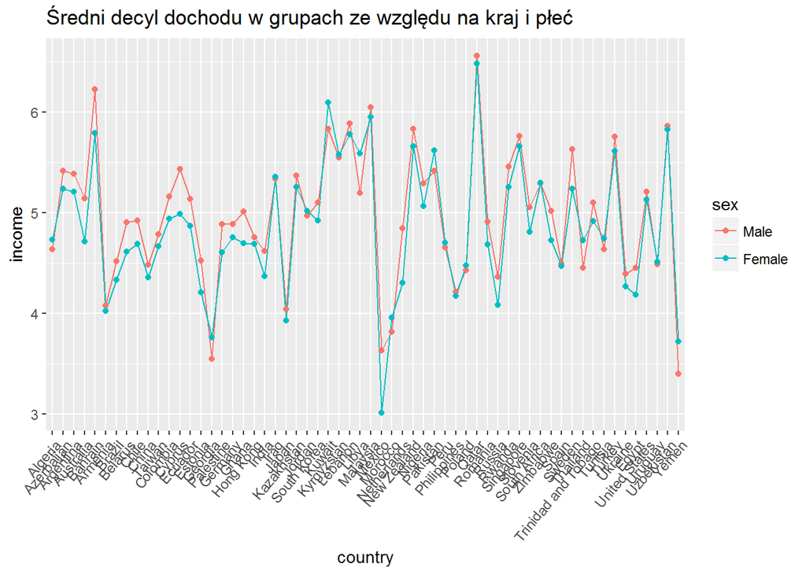

```r
ggplot(df[!is.na(df$sex),], aes(x = country, y = income, colour = sex, group = sex)) + stat_summary(fun.y = mean, geom = "line") + stat_summary(fun.y = mean, geom = "point") + ggtitle("Średni decyl dochodu w grupach ze względu na kraj i płeć") + theme(axis.text.x=element_text(angle = 50, hjust = 1))
```

Przedstawiona poniżej analiza wariancji potwierdza istotność zarówno efektu kraju jak i płci zagnieżdżonej w kraju. Następnie pokażemy oszacowania parametrów powstałego modelu.

```r
anova(modelCountrySex <- lm(income ~ country/sex, data = df))
```

```
## Analysis of Variance Table
##
## Response: income
##                Df Sum Sq Mean Sq  F value    Pr(>F)
## country        59  33872  574.10 141.5652 < 2.2e-16 ***
## country:sex    60   1235   20.59   5.0765 < 2.2e-16 ***
## Residuals   87063 353075    4.06
## ---
## Signif. codes:  0 '***' 0.001 '**' 0.01 '*' 0.05 '.' 0.1 ' ' 1
```

```r
summary(modelCountrySex)
```

```
##
## Call:
## lm(formula = income ~ country/sex, data = df)
##
## Residuals:
##     Min      1Q  Median      3Q     Max
## -5.5549 -1.3848  0.0792  1.3659  6.9907
##
## Coefficients:
##                                       Estimate Std. Error t value Pr(>|t|)
## (Intercept)                           4.638158   0.081670  56.791  < 2e-16 ***
## countryAzerbaijan                     0.775016   0.121510   6.378 1.80e-10 ***
## countryArgentina                      0.746625   0.124443   6.000 1.98e-09 ***
## countryAustralia                      0.504022   0.114353   4.408 1.05e-05 ***
## countryBahrain                        1.587168   0.119256  13.309  < 2e-16 ***
## countryArmenia                       -0.564987   0.132892  -4.251 2.13e-05 ***
## countryBrazil                        -0.120917   0.118449  -1.021 0.307336
## countryBelarus                        0.264209   0.112557   2.347 0.018911 *
## countryChile                          0.282372   0.124989   2.259 0.023875 *
## countryChina                         -0.158827   0.103255  -1.538 0.124002
## countryTaiwan                         0.144911   0.117569   1.233 0.217742
## countryColombia                       0.520872   0.110161   4.728 2.27e-06 ***
## countryCyprus                         0.792914   0.124676   6.360 2.03e-10 ***
## countryEcuador                        0.499299   0.116782   4.275 1.91e-05 ***
## countryEstonia                       -0.118276   0.112440  -1.052 0.292846
## countryGeorgia                       -1.089712   0.118676  -9.182  < 2e-16 ***
## countryPalestine                      0.249137   0.122394   2.036 0.041800 *
## countryGermany                        0.245158   0.104024   2.357 0.018438 *
## countryGhana                          0.370816   0.108946   3.404 0.000665 ***
## countryHong Kong                      0.118479   0.125069   0.947 0.343481
## countryIndia                         -0.022370   0.088998  -0.251 0.801540
## countryIraq                           0.701586   0.114757   6.114 9.78e-10 ***
## countryJapan                         -0.599119   0.103583  -5.784 7.32e-09 ***
## countryKazakhstan                     0.727162   0.116178   6.259 3.89e-10 ***
## countryJordan                         0.331691   0.116030   2.859 0.004255 **
## countrySouth Korea                    0.458616   0.116427   3.939 8.19e-05 ***
## countryKuwait                         1.196074   0.110161  10.857  < 2e-16 ***
## countryKyrgyzstan                     0.906794   0.110811   8.183 2.80e-16 ***
## countryLebanon                        1.246919   0.116731  10.682  < 2e-16 ***
## countryLibya                          0.555451   0.102379   5.425 5.80e-08 ***
```

[output cut: 82 more lines]

```
## countryTunisia:sexFemale              0.106113   0.118819   0.893 0.371825
## countryTurkey:sexFemale              -0.141766   0.101665  -1.394 0.163186
## countryUkraine:sexFemale             -0.130000   0.106137  -1.225 0.220640
## countryEgypt:sexFemale               -0.270099   0.110463  -2.445 0.014481 *
## countryUnited States:sexFemale       -0.077164   0.086545  -0.892 0.372606
## countryUruguay:sexFemale              0.022543   0.129251   0.174 0.861544
## countryUzbekistan:sexFemale          -0.034053   0.107754  -0.316 0.751984
## countryYemen:sexFemale                0.321393   0.129499   2.482 0.013073 *
## ---
## Signif. codes:  0 '***' 0.001 '**' 0.01 '*' 0.05 '.' 0.1 ' ' 1
##
## Residual standard error: 2.014 on 87063 degrees of freedom
##   (43 observations deleted due to missingness)
## Multiple R-squared:  0.09044,    Adjusted R-squared:  0.0892
## F-statistic: 72.75 on 119 and 87063 DF,  p-value: < 2.2e-16
```

Powyższe oszacowania pokazują, że kraje są zróżnicowane pod względem średnich dochodów (oznacza to, że kształt rozkładu dochodów jest zróżnicowany, a nie nominalny dochód, ponieważ analizujemy decyle) i niektóre z nich charakteryzują się również zróżnicowaniem między płciami. Przykładowo, dla Estonii efekt kraju jest nieistotny, ale estońskie kobiety zarabiają istotnie mniej niż średnia. Z drugiej strony efekt Niemiec jest istotny (przy poziomie istotności 0.05), ale już efekt płci w Niemczech - nie.

# Wnioski

Podsumowując, analizy interakcji typu crossed i nested różnią się przede wszystkim koncepcyjnie. Jeśli spodziewamy się efektu interakcji (np. na podstawie interaction plot), to należy zastanowić się, który rodzaj efektu interakcji ma sens pod względem interpretacji, co jest przede wszystkim decyzją modelującego.